# Case Study 2 - Modeling Wine Quality

### Introduction

In this case-study, we will model wine quality using a [Gradient Boosting Classifier](https://scikit-learn.org/stable/modules/generated/sklearn.ensemble.GradientBoostingClassifier.html) model from the "sklearn" library. We will use it to classify data into multiple groups of "quality" buckets. We will build a dashboard with real-time sliders to create new wines and measure their quality.

The Wine Quality Data Set along with additional information about can be found on the [UCI Machine Learning Repository](https://archive.ics.uci.edu/ml/datasets/wine+quality)

To get this web application running in real-time, we will use [Ajax](http://flask.pocoo.org/docs/1.0/patterns/jquery/), a powerful technology that can update web content without rebuilding the entire page. It consists of two pieces, a front-end script function calling "$.ajax " and a back-end Flask function to catch and process the calls.

**Load red and white wine quality data sets**

```python
import pandas as pd
import numpy as np
import matplotlib.pyplot as plt
import pickle
import warnings
from sklearn.model_selection import train_test_split
from IPython.display import display, HTML
warnings.filterwarnings('ignore')

def plot_confusion_matrix(cm, classes,
                          normalize=False,
                          title='Confusion matrix',
                          cmap=plt.cm.Blues):
    """
    Source:
    http://scikit-learn.org/stable/auto_examples/model_selection/plot_confusion_matrix.html
    This function prints and plots the confusion matrix.
    Normalization can be applied by setting `normalize=True`.
    """
    import itertools
    if normalize:
        cm = cm.astype('float') / cm.sum(axis=1)[:, np.newaxis]
        print("Normalized confusion matrix")
    else:
        print('Confusion matrix, without normalization')

    print(cm)

    plt.imshow(cm, interpolation='nearest', cmap=cmap)
    plt.title(title)
    plt.colorbar()
    tick_marks = np.arange(len(classes))
    plt.xticks(tick_marks, classes, rotation=45)
    plt.yticks(tick_marks, classes)

    fmt = '.2f' if normalize else 'd'
    thresh = cm.max() / 2.
    for i, j in itertools.product(range(cm.shape[0]), range(cm.shape[1])):
        plt.text(j, i, format(cm[i, j], fmt),
                 horizontalalignment="center",
                 color="white" if cm[i, j] > thresh else "black")

    plt.tight_layout()
    plt.ylabel('True label')
    plt.xlabel('Predicted label')
```

```python
# if you cannot download the files try doing it manually
# if have an ssl error  Mac try fix: "/Applications/Python\ 3.6/Install\ Certificates.command"

red = pd.read_csv("http://archive.ics.uci.edu/ml/machine-learning-databases/wine-quality/winequality-red.csv",
                  sep=";")
print('red', len(red))
white = pd.read_csv("http://archive.ics.uci.edu/ml/machine-learning-databases/wine-quality/winequality-white.csv",
                    sep=";")
print('white', len(white))
```

```
red 1599
white 4898
```

```python
white.head()
```

|  | fixed acidity | volatile acidity | citric acid | residual sugar | chlorides | free sulfur dioxide | total sulfur dioxide | density | pH | sulphates | alcohol | quality |
| --- | --- | --- | --- | --- | --- | --- | --- | --- | --- | --- | --- | --- |
| 0 | 7.0 | 0.27 | 0.36 | 20.7 | 0.045 | 45.0 | 170.0 | 1.0010 | 3.00 | 0.45 | 8.8 | 6 |
| 1 | 6.3 | 0.30 | 0.34 | 1.6 | 0.049 | 14.0 | 132.0 | 0.9940 | 3.30 | 0.49 | 9.5 | 6 |
| 2 | 8.1 | 0.28 | 0.40 | 6.9 | 0.050 | 30.0 | 97.0 | 0.9951 | 3.26 | 0.44 | 10.1 | 6 |
| 3 | 7.2 | 0.23 | 0.32 | 8.5 | 0.058 | 47.0 | 186.0 | 0.9956 | 3.19 | 0.40 | 9.9 | 6 |
| 4 | 7.2 | 0.23 | 0.32 | 8.5 | 0.058 | 47.0 | 186.0 | 0.9956 | 3.19 | 0.40 | 9.9 | 6 |

```python
red.head()
```

|  | fixed acidity | volatile acidity | citric acid | residual sugar | chlorides | free sulfur dioxide | total sulfur dioxide | density | pH | sulphates | alcohol | quality |
| --- | --- | --- | --- | --- | --- | --- | --- | --- | --- | --- | --- | --- |
| 0 | 7.4 | 0.70 | 0.00 | 1.9 | 0.076 | 11.0 | 34.0 | 0.9978 | 3.51 | 0.56 | 9.4 | 5 |
| 1 | 7.8 | 0.88 | 0.00 | 2.6 | 0.098 | 25.0 | 67.0 | 0.9968 | 3.20 | 0.68 | 9.8 | 5 |
| 2 | 7.8 | 0.76 | 0.04 | 2.3 | 0.092 | 15.0 | 54.0 | 0.9970 | 3.26 | 0.65 | 9.8 | 5 |
| 3 | 11.2 | 0.28 | 0.56 | 1.9 | 0.075 | 17.0 | 60.0 | 0.9980 | 3.16 | 0.58 | 9.8 | 6 |
| 4 | 7.4 | 0.70 | 0.00 | 1.9 | 0.076 | 11.0 | 34.0 | 0.9978 | 3.51 | 0.56 | 9.4 | 5 |

**Merge both data sets together**

```python
# create a new wine color feature
white['color'] = 0
red['color'] = 1

# concat both data sets together
wine_df = pd.concat([white, red], ignore_index=True)
wine_df.head()
```

|  | fixed acidity | volatile acidity | citric acid | residual sugar | chlorides | free sulfur dioxide | total sulfur dioxide | density | pH | sulphates | alcohol | quality | color |
| --- | --- | --- | --- | --- | --- | --- | --- | --- | --- | --- | --- | --- | --- |
| 0 | 7.0 | 0.27 | 0.36 | 20.7 | 0.045 | 45.0 | 170.0 | 1.0010 | 3.00 | 0.45 | 8.8 | 6 | 0 |
| 1 | 6.3 | 0.30 | 0.34 | 1.6 | 0.049 | 14.0 | 132.0 | 0.9940 | 3.30 | 0.49 | 9.5 | 6 | 0 |
| 2 | 8.1 | 0.28 | 0.40 | 6.9 | 0.050 | 30.0 | 97.0 | 0.9951 | 3.26 | 0.44 | 10.1 | 6 | 0 |
| 3 | 7.2 | 0.23 | 0.32 | 8.5 | 0.058 | 47.0 | 186.0 | 0.9956 | 3.19 | 0.40 | 9.9 | 6 | 0 |
| 4 | 7.2 | 0.23 | 0.32 | 8.5 | 0.058 | 47.0 | 186.0 | 0.9956 | 3.19 | 0.40 | 9.9 | 6 | 0 |

## Explore the Data

```python
# feature data types
wine_df.info()

# display(HTML(pd.DataFrame(wine_df.info()).to_html()))
```

```
<class 'pandas.core.frame.DataFrame'>
RangeIndex: 6497 entries, 0 to 6496
Data columns (total 13 columns):
fixed acidity           6497 non-null float64
volatile acidity        6497 non-null float64
citric acid             6497 non-null float64
residual sugar          6497 non-null float64
chlorides               6497 non-null float64
free sulfur dioxide     6497 non-null float64
total sulfur dioxide    6497 non-null float64
density                 6497 non-null float64
pH                      6497 non-null float64
sulphates               6497 non-null float64
alcohol                 6497 non-null float64
quality                 6497 non-null int64
color                   6497 non-null int64
dtypes: float64(11), int64(2)
memory usage: 659.9 KB
```

```python
wine_df.describe()
```

|  | fixed acidity | volatile acidity | citric acid | residual sugar | chlorides | free sulfur dioxide | total sulfur dioxide | density | pH | sulphates | alcohol | quality | color |
| --- | --- | --- | --- | --- | --- | --- | --- | --- | --- | --- | --- | --- | --- |
| count | 6497.000000 | 6497.000000 | 6497.000000 | 6497.000000 | 6497.000000 | 6497.000000 | 6497.000000 | 6497.000000 | 6497.000000 | 6497.000000 | 6497.000000 | 6497.000000 | 6497.000000 |
| mean | 7.215307 | 0.339666 | 0.318633 | 5.443235 | 0.056034 | 30.525319 | 115.744574 | 0.994697 | 3.218501 | 0.531268 | 10.491801 | 5.818378 | 0.246114 |
| std | 1.296434 | 0.164636 | 0.145318 | 4.757804 | 0.035034 | 17.749400 | 56.521855 | 0.002999 | 0.160787 | 0.148806 | 1.192712 | 0.873255 | 0.430779 |
| min | 3.800000 | 0.080000 | 0.000000 | 0.600000 | 0.009000 | 1.000000 | 6.000000 | 0.987110 | 2.720000 | 0.220000 | 8.000000 | 3.000000 | 0.000000 |
| 25% | 6.400000 | 0.230000 | 0.250000 | 1.800000 | 0.038000 | 17.000000 | 77.000000 | 0.992340 | 3.110000 | 0.430000 | 9.500000 | 5.000000 | 0.000000 |
| 50% | 7.000000 | 0.290000 | 0.310000 | 3.000000 | 0.047000 | 29.000000 | 118.000000 | 0.994890 | 3.210000 | 0.510000 | 10.300000 | 6.000000 | 0.000000 |
| 75% | 7.700000 | 0.400000 | 0.390000 | 8.100000 | 0.065000 | 41.000000 | 156.000000 | 0.996990 | 3.320000 | 0.600000 | 11.300000 | 6.000000 | 0.000000 |
| max | 15.900000 | 1.580000 | 1.660000 | 65.800000 | 0.611000 | 289.000000 | 440.000000 | 1.038980 | 4.010000 | 2.000000 | 14.900000 | 9.000000 | 1.000000 |

```python
# what about our outcome column?
wine_df['quality'].value_counts()
```

```
6    2836
5    2138
7    1079
4     216
8     193
3      30
9       5
Name: quality, dtype: int64
```

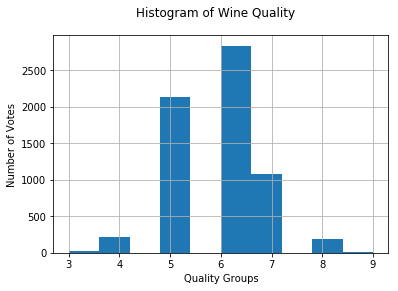

```python
wine_df['quality'].hist()
plt.suptitle('Histogram of Wine Quality')
plt.xlabel('Quality Groups')
plt.ylabel('Number of Votes')
plt.show()
```

**What can we do to classify this data with such imbalannced edges?**

```python
# try balancing the data somewhat by limiting each category to 500 samples
wine_quality_scale = set(wine_df['quality'])

temp_df = []
for quality in wine_quality_scale:
    wine_df_tmp = wine_df[wine_df['quality']==quality]
    # sample down any categories with ovrer 500 entries
    if (len(wine_df_tmp) > 500):
        wine_df_tmp = wine_df_tmp.sample(500, replace=False)
    temp_df.append(wine_df_tmp)
len(temp_df)

wine_balanced_df = pd.concat(temp_df)

print(wine_balanced_df['quality'].value_counts())
```

```
7    500
6    500
5    500
4    216
8    193
3     30
9      5
Name: quality, dtype: int64
```

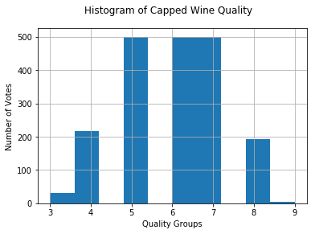

```python
wine_balanced_df['quality'].hist()
plt.suptitle('Histogram of Capped Wine Quality')
plt.xlabel('Quality Groups')
plt.ylabel('Number of Votes')
plt.show()
```

**The edges still are imbalanced, so a better way would be re-balance the groupings:**

| Old Quality | New Quality |
| --- | --- |
| 3,4,5 | 3 |
| 6 | 6 |
| 7,8,9 | 9 |

```python
# balance categories more equally
wine_df_bad = wine_df[wine_df['quality'].isin([3,4,5])]
wine_df_bad['quality'] = 3
wind_df_average = wine_df[wine_df['quality']==6]
wind_df_average['quality'] = 6
wind_df_good = wine_df[wine_df['quality'].isin([7,8,9])]
wind_df_good['quality'] = 9
wine_df = pd.concat([wine_df_bad,wind_df_average,wind_df_good], ignore_index=True)

# save a copy to file for our web application
wine_df.to_csv('wine_df.csv', index=False)

print(wine_df['quality'].value_counts())
```

```
6    2836
3    2384
9    1277
Name: quality, dtype: int64
```

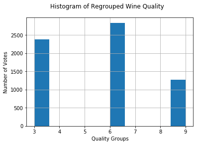

```python
wine_df['quality'].hist()
plt.suptitle('Histogram of Regrouped Wine Quality')
plt.xlabel('Quality Groups')
plt.ylabel('Number of Votes')
plt.show()
```

```python
wine_df.head()
```

|  | fixed acidity | volatile acidity | citric acid | residual sugar | chlorides | free sulfur dioxide | total sulfur dioxide | density | pH | sulphates | alcohol | quality | color |
| --- | --- | --- | --- | --- | --- | --- | --- | --- | --- | --- | --- | --- | --- |
| 0 | 8.1 | 0.27 | 0.41 | 1.45 | 0.033 | 11.0 | 63.0 | 0.9908 | 2.99 | 0.56 | 12.0 | 3 | 0 |
| 1 | 8.6 | 0.23 | 0.40 | 4.20 | 0.035 | 17.0 | 109.0 | 0.9947 | 3.14 | 0.53 | 9.7 | 3 | 0 |
| 2 | 7.9 | 0.18 | 0.37 | 1.20 | 0.040 | 16.0 | 75.0 | 0.9920 | 3.18 | 0.63 | 10.8 | 3 | 0 |
| 3 | 8.3 | 0.42 | 0.62 | 19.25 | 0.040 | 41.0 | 172.0 | 1.0002 | 2.98 | 0.67 | 9.7 | 3 | 0 |
| 4 | 6.5 | 0.31 | 0.14 | 7.50 | 0.044 | 34.0 | 133.0 | 0.9955 | 3.22 | 0.50 | 9.5 | 3 | 0 |

## It's Modeling Time

We're going to train the model then persist it (i.e. save it) to file by using the **pickle()** function. When a model is too big or takes too long to model, it is best to use a pre-trained version of it so we only need to do that work once. We will also be able to upload the pre-trained model to the cloud.

Notes:

A note on Pickle Python versions - it has compatibility issues between 2.x and 3.x versions so please stick to Python 3.x

pip3 install scikit-learn

pip3 install scipy

```python
from sklearn.model_selection import train_test_split

features = [ft for ft in list(wine_df) if ft not in ['quality']]
wine_df['quality'] = pd.Categorical(wine_df['quality'])
wine_df['quality_class'] = wine_df['quality'].cat.codes
outcome = 'quality_class'
outcome_buckets = len(set(wine_df['quality_class']))
print(set(wine_df['quality_class']))

X_train, X_test, y_train, y_test = train_test_split(wine_df[features],
                        wine_df[outcome], test_size=0.2, random_state=1)
print(("len(X_train): %i, len(X_test): %i, len(y_train): %i, len(y_test): %i") % (len(X_train),
                                                                               len(X_test),
                                                                               len(y_train),
                                                                               len(y_test)))
```

```
{0, 1, 2}
len(X_train): 5197, len(X_test): 1300, len(y_train): 5197, len(y_test): 1300
```

### The sklearn GradientBoostingClassifier Algorithm

Gradient Boosting for classification builds an additive model in a forward stage-wise fashion; it allows for the optimization of arbitrary differentiable loss functions. In each stage n*classes* regression trees are fit on the negative gradient of the binomial or multinomial deviance loss function. Binary classification is a special case where only a single regression tree is induced.

- Docs: sklearn.ensemble.GradientBoostingClassifier

Here are some of the critical parameters copied from the scikit-learn help files (more parameters and explanation at scikit-learn.org )

- learning_rate: (default=0.1) Learning rate shrinks the contribution of each tree by learning_rate. There is a trade-off between learning_rate and n_estimators.
- n_estimators: (default=100) The number of boosting stages to perform. Gradient boosting is fairly robust to over-fitting, so a large number usually results in better performance.
- max_depth: (default=3) Maximum depth of the individual regression estimators. The maximum depth limits the number of nodes in the tree. Tune this parameter for best performance; the best value depends on the interaction of the input variables.
- max_features: (default=None) The number of features to consider when looking for the best split.
- random_state: (default=None). If int, random_state is the seed used by the random number generator.

```python
from sklearn.ensemble import GradientBoostingClassifier  #GBM algorithm

gbm_model = GradientBoostingClassifier(random_state=10, learning_rate=0.1, max_depth=10)
gbm_model.fit(X_train[features], y_train)

# save the model so we don't have to train it in the web application
with open('gbm_model_dump.p', 'wb') as f:
    pickle.dump(gbm_model, f, 2)

gbm_model = pickle.load(open("gbm_model_dump.p", "rb" ))

preds = gbm_model.predict_proba(X_test)
preds
```

```
array([[0.50623207, 0.48718144, 0.00658649],
       [0.00207022, 0.06547176, 0.93245802],
       [0.76888383, 0.22809148, 0.00302469],
       ...,
       [0.13809377, 0.85149348, 0.01041275],
       [0.97428507, 0.02471198, 0.00100295],
       [0.97347543, 0.02518674, 0.00133783]])
```

```python
print(preds.shape)
preds[0]
```

```
(1300, 3)
```

```
array([0.50623207, 0.48718144, 0.00658649])
```

```python
list(wine_df['quality'].cat.categories)
```

```
[3, 6, 9]
```

```python
print('Argmax: %i' % np.argmax(preds[0]))
print('Quality class: %i' % list(wine_df['quality'].cat.categories)[np.argmax(preds[0])])
```

```
Argmax: 0
Quality class: 3
```

### Getting the precision of the model using the precision_score() function

We'll use sklearn.metrics "precision_score()" function. This will return a number between 0 and 1, where 0 is the worst score and 1, the best. Precision is better than accuracy in this case because we aren't talking about a simple binary prediction of a well-balanced data set, instead we want to know how well the model chooses between 3 quality classes for a particular wine on an imbalanced data set.

```python
# get highest probability for each quality classes
from sklearn.metrics import precision_score
best_preds = np.asarray([np.argmax(line) for line in preds])
print ("Precision_score: %0.2f" % precision_score(y_test, best_preds, average='macro'))
```

```
Precision_score: 0.74
```

```python
set(wine_df['quality'])
```

```
{3, 6, 9}
```

### The Confusion Matrix

A confusion matrix is very useful to visualize multi-class models. The 'plot_confusion_matrix()' function will plot a large square matrix which shows the model's best predictions against the ground truth. The code to produce these graphical matrices comes directly from scikit-learn.org help files on confusion matrices.

```
Confusion matrix, without normalization
[[345 112   7]
 [ 95 448  46]
 [  7  80 160]]
```

[figure not shown]

```python
# confusion matrix
from sklearn.metrics import confusion_matrix

# Compute confusion matrix
cnf_matrix = confusion_matrix(y_test, best_preds)

# Plot non-normalized confusion matrix
import matplotlib.pyplot as plt
plt.figure()
# use actual labels, not outcome code
plot_confusion_matrix(cnf_matrix, classes=list(wine_df['quality'].cat.categories),
                      title='Confusion matrix')

plt.show()
```

The X axis represents the best predictions and the Y axis represents the ground truth using the best predictions from our GradientBoostingClassifier model.

## Test predicting wine using new data

Let's get this abstracted into a clean function to create new ones from our web application. First, let's extract the mean values for each feature and use those values to predict the quality of the wine. In essence, we are going to create an average wine using the means and we will use the min/max values to calibrate our sliders.

Get means, min, and max of all quantitative features to populate web application

```python
fixed_acidity = np.mean(wine_df['fixed acidity']) # 7.215307
print('fixed_acidity: %f' % fixed_acidity)
print(('fixed_acidity min: %f, max: %f') % (np.min(wine_df['fixed acidity']), np.max(wine_df['fixed acidity'])))
print('--')

volatile_acidity = np.mean(wine_df['volatile acidity'])
print('volatile_acidity: %f' % volatile_acidity)
print(('volatile_acidity min: %f, max: %f') % (np.min(wine_df['volatile acidity']), np.max(wine_df['volatile acidity'])))
print('--')

citric_acid = np.mean(wine_df['citric acid'])
print('citric_acid: %f' % citric_acid)
print(('citric_acid min: %f, max: %f') % (np.min(wine_df['citric acid']), np.max(wine_df['citric acid'])))
print('--')

residual_sugar = np.mean(wine_df['residual sugar'])
print('residual_sugar: %f' % residual_sugar)
print(('residual_sugar min: %f, max: %f') % (np.min(wine_df['residual sugar']), np.max(wine_df['residual sugar'])))
print('--')

chlorides = np.mean(wine_df['chlorides'])
print('chlorides: %f' % chlorides)
print(('chlorides min: %f, max: %f') % (np.min(wine_df['chlorides']), np.max(wine_df['chlorides'])))
print('--')

free_sulfur_dioxide = np.mean(wine_df['free sulfur dioxide'])
print('free sulfur dioxide: %f' % free_sulfur_dioxide)
print(('free sulfur dioxide: %f, max: %f') % (np.min(wine_df['free sulfur dioxide']), np.max(wine_df['free sulfur dioxide'])))
print('--')

total_sulfur_dioxide = np.mean(wine_df['total sulfur dioxide'])
print('total_sulfur_dioxide: %f' % total_sulfur_dioxide)
print(('total sulfur dioxide: %f, max: %f') % (np.min(wine_df['total sulfur dioxide']), np.max(wine_df['total sulfur dioxide'])))
print('--')

density = np.mean(wine_df['density'])
print('density: %f' % density)
print(('density: %f, max: %f') % (np.min(wine_df['density']), np.max(wine_df['density'])))
print('--')

pH = np.mean(wine_df['pH'])
print('pH: %f' % pH)
print(('pH: %f, max: %f') % (np.min(wine_df['pH']), np.max(wine_df['pH'])))
print('--')

sulphates = np.mean(wine_df['sulphates'])
print('sulphates: %f' % sulphates)
print(('sulphates: %f, max: %f') % (np.min(wine_df['sulphates']), np.max(wine_df['sulphates'])))
print('--')

alcohol = np.mean(wine_df['alcohol'])
print('alcohol: %f' % alcohol)
print(('alcohol: %f, max: %f') % (np.min(wine_df['alcohol']), np.max(wine_df['alcohol'])))
print('--')

color = np.mean(wine_df['color'])
print('color: %i' % round(color))
print(('color: %f, max: %f') % (np.min(wine_df['color']), np.max(wine_df['color'])))
print('--')

color = 0
```

```
fixed_acidity: 7.215307
fixed_acidity min: 3.800000, max: 15.900000
--
volatile_acidity: 0.339666
volatile_acidity min: 0.080000, max: 1.580000
--
citric_acid: 0.318633
citric_acid min: 0.000000, max: 1.660000
--
residual_sugar: 5.443235
residual_sugar min: 0.600000, max: 65.800000
--
chlorides: 0.056034
chlorides min: 0.009000, max: 0.611000
--
free sulfur dioxide: 30.525319
free sulfur dioxide: 1.000000, max: 289.000000
--
total_sulfur_dioxide: 115.744574
total sulfur dioxide: 6.000000, max: 440.000000
--
density: 0.994697
density: 0.987110, max: 1.038980
--
pH: 3.218501
pH: 2.720000, max: 4.010000
--
sulphates: 0.531268
sulphates: 0.220000, max: 2.000000
--
alcohol: 10.491801
alcohol: 8.000000, max: 14.900000
--
color: 0
color: 0.000000, max: 1.000000
--
```

```python
# test predicting wine entry from new data
# default wine constants based on data mean values

# create data set of new data
x_test_tmp = pd.DataFrame([[fixed_acidity,
                                 volatile_acidity,
                                 citric_acid,
                                 residual_sugar,
                                 chlorides,
                                 free_sulfur_dioxide,
                                 total_sulfur_dioxide,
                                 density,
                                 pH,
                                 sulphates,
                                 alcohol,
                                 color]], columns = X_test.columns.values)

# predict quality based on incoming values
preds = gbm_model.predict_proba((x_test_tmp))
```

```python
list(wine_df['quality'].cat.categories)[np.argmax(preds)]
```

```
6
```

```python
features
```

```
['fixed acidity',
 'volatile acidity',
 'citric acid',
 'residual sugar',
 'chlorides',
 'free sulfur dioxide',
 'total sulfur dioxide',
 'density',
 'pH',
 'sulphates',
 'alcohol',
 'color']
```

```python
# get best quality prediction from original quality scale
print(('Predicted wine quality: %i') % list(wine_df['quality'].cat.categories)[np.argmax(preds)])
# get mean quality to compare
print(('Actual mean wine quality: %0.2f') % np.mean(wine_df['quality'].values))
```

```
Predicted wine quality: 6
Actual mean wine quality: 5.49
```

```python
preds
```

```
array([[0.34124871, 0.63933304, 0.01941825]])
```

```python
x_test_tmp
```

|  | fixed acidity | volatile acidity | citric acid | residual sugar | chlorides | free sulfur dioxide | total sulfur dioxide | density | pH | sulphates | alcohol | color |
| --- | --- | --- | --- | --- | --- | --- | --- | --- | --- | --- | --- | --- |
| 0 | 7.215307 | 0.339666 | 0.318633 | 5.443235 | 0.056034 | 30.525319 | 115.744574 | 0.994697 | 3.218501 | 0.531268 | 10.491801 | 0 |

## Building out our Web Application

```
Create a folder called 'predicting_wine' and create the following structure:

predicting_wine/
├── main.py
├── static/
    └── images/
        ├── wine_red_3.jpg
        ├── wine_red_6.jpg
        ├── wine_red_9.jpg
        ├── wine_white_3.jpg
        ├── wine_white_6.jpg
        └── wine_white_9.jpg
    └── pickles/
        └── gbm_model_dump.p
└── templates/
        └── wine.html
```

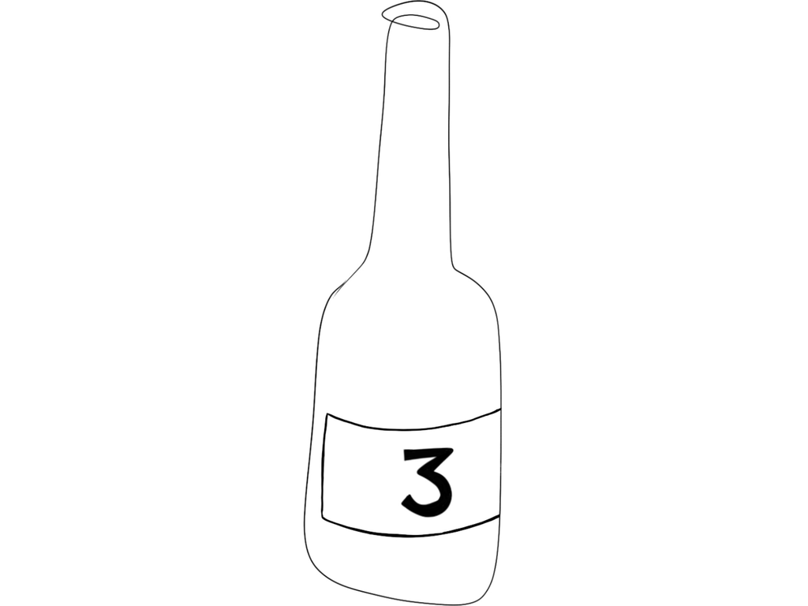

```python
from IPython.display import Image
Image(filename="static/images/wine_red_3.jpg")
```

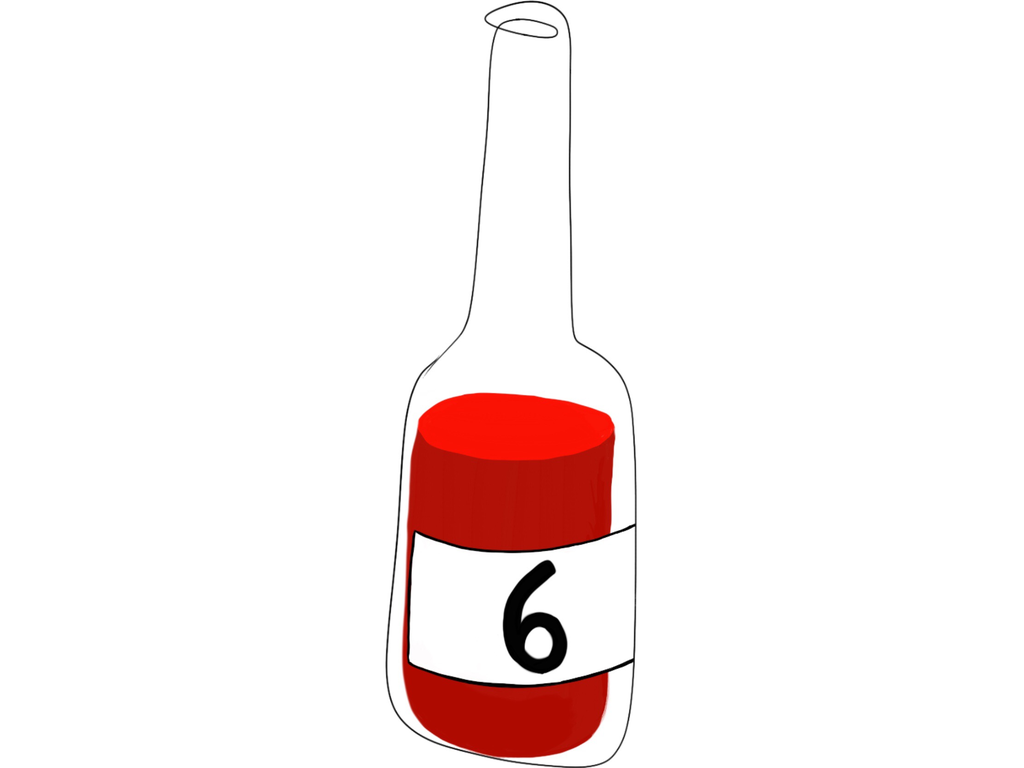

```python
Image(filename="static/images/wine_red_6.jpg")
```

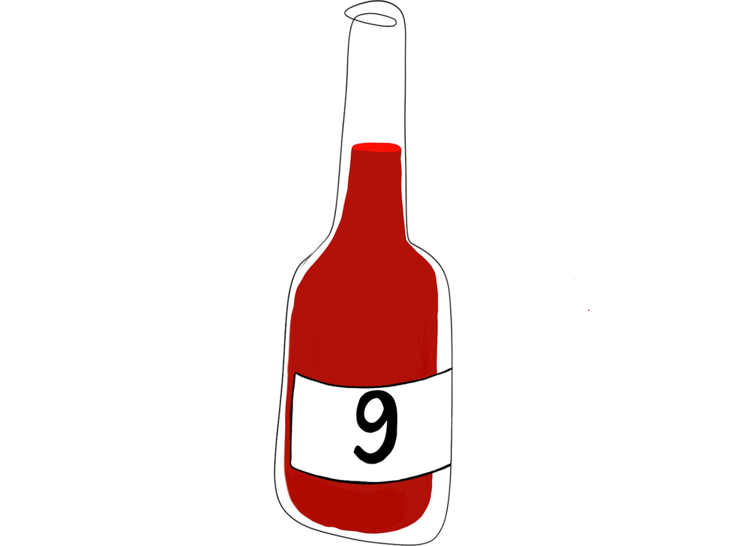

```python
Image(filename="static/images/wine_red_9.jpg")
```

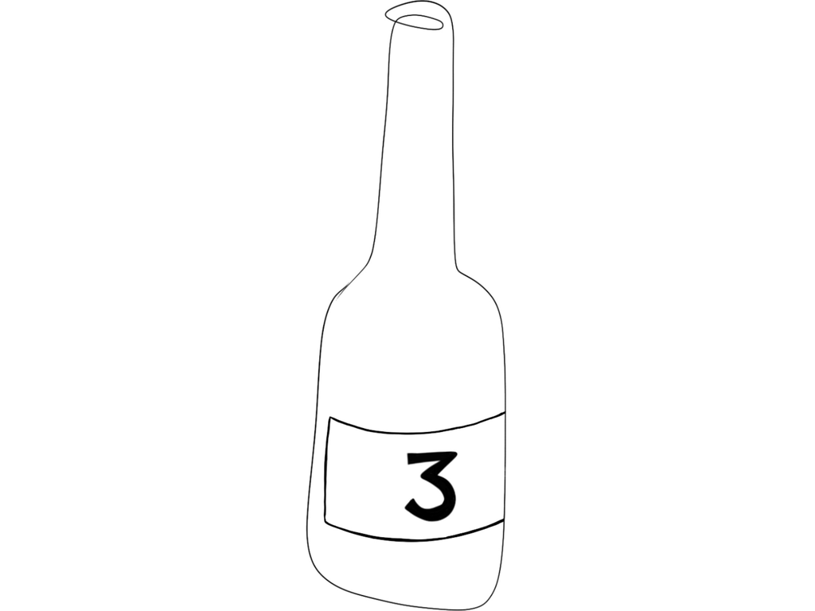

```python
Image(filename="static/images/wine_white_3.jpg")
```

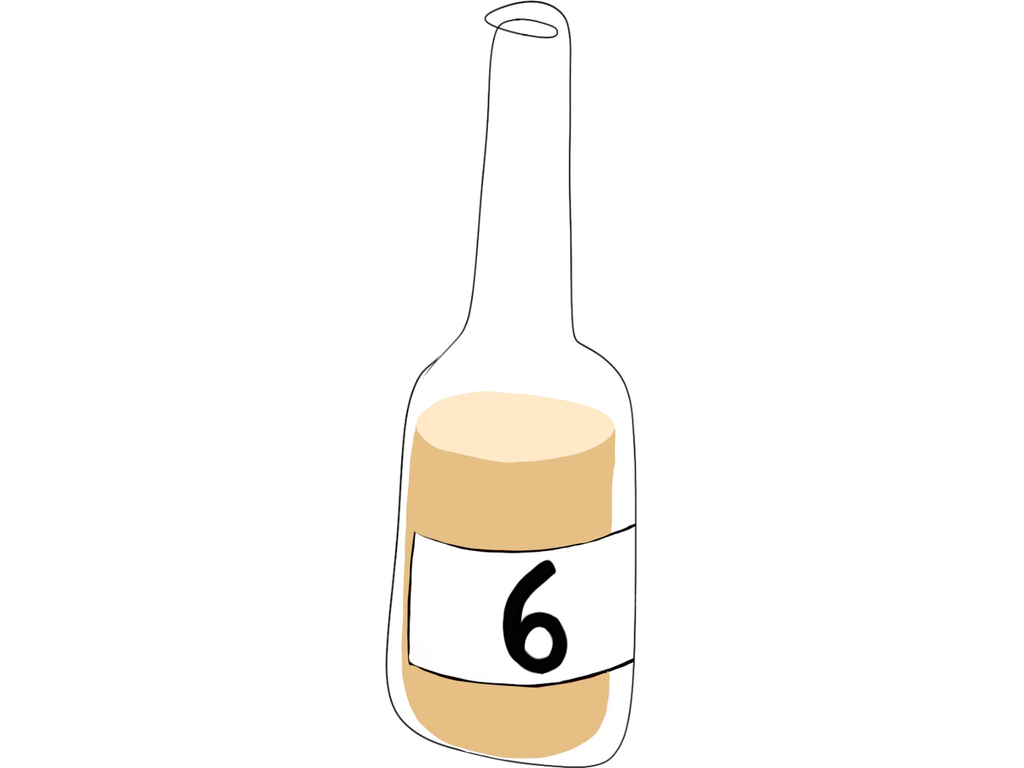

```python
Image(filename="static/images/wine_white_6.jpg")
```

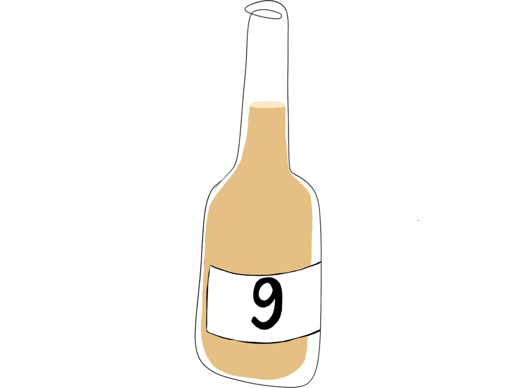

```python
Image(filename="static/images/wine_white_9.jpg")
```

Let's build out our "main.py" file.

```
#!/usr/bin/env python
from flask import Flask, render_template, flash, request, jsonify, Markup
import logging, io, os, sys
import pandas as pd
import numpy as np
from sklearn.ensemble import GradientBoostingClassifier
import scipy
import pickle

app = Flask(__name__)
app.config["DEBUG"] = True

# model related variables
gbm_model = None
features = ['fixed acidity',
            'volatile acidity',
            'citric acid',
            'residual sugar',
            'chlorides',
            'free sulfur dioxide',
            'total sulfur dioxide',
            'density',
            'pH',
            'sulphates',
            'alcohol',
            'color']

def get_wine_image_to_show(wine_color, wine_quality):
    if wine_color == 0:
        wine_color_str = 'white'
    else:
        wine_color_str = 'red'
    return('/static/images/wine_' + wine_color_str + '_' + str(wine_quality) + '.jpg')

@app.before_first_request
def startup():
    global gbm_model

    # load saved model from web app root directory
    gbm_model = pickle.load(open("static/pickles/gbm_model_dump.p",'rb'))


@app.errorhandler(500)
def server_error(e):
    logging.exception('some eror')
    return """
    And internal error <pre>{}</pre>
    """.format(e), 500

@app.route('/background_process', methods=['POST', 'GET'])
def background_process():
    fixed_acidity = float(request.args.get('fixed_acidity'))
    volatile_acidity = float(request.args.get('volatile_acidity'))
    citric_acid = float(request.args.get('citric_acid'))
    residual_sugar = float(request.args.get('residual_sugar'))
    chlorides = float(request.args.get('chlorides'))
    free_sulfur_dioxide = float(request.args.get('free_sulfur_dioxide'))
    total_sulfur_dioxide = float(request.args.get('total_sulfur_dioxide'))
    density = float(request.args.get('density'))
    pH = float(request.args.get('pH'))
    sulphates = float(request.args.get('sulphates'))
    alcohol = float(request.args.get('alcohol'))
    color = int(request.args.get('color'))


    # create data set of new data
    x_test_tmp = pd.DataFrame([[fixed_acidity,
        volatile_acidity,
        citric_acid,
        residual_sugar,
        chlorides,
        free_sulfur_dioxide,
        total_sulfur_dioxide,
        density,
        pH,
        sulphates,
        alcohol,
        color]], columns = features)


    # predict quality based on incoming values
    preds = gbm_model.predict_proba(x_test_tmp[features])

    # get best quality prediction from original quality scale
    predicted_quality = [3,6,9][np.argmax(preds[0])]
    return jsonify({'quality_prediction':predicted_quality, 'image_name': get_wine_image_to_show(color, predicted_quality)})


@app.route("/", methods=['POST', 'GET'])
def show_wine():
    # on load set form with defaults
    return render_template('wine.html', quality_prediction=1, image_name='/static/images/wine_red_6.jpg')

# when running app locally
if __name__=='__main__':
    app.run(debug=True)
```

### wine.html

Still in your favorite text editor or IDE create an HTML file called "wine.html" and copy/paste the below code into it:

```
<!DOCTYPE html>
<HTML>
<HEAD>
    <meta name="viewport" content="width=device-width, initial-scale=1">
    <meta charset="UTF=8">
    <title>Wine Quality Designer</title>
    <script src="//ajax.googleapis.com/ajax/libs/jquery/3.3.1/jquery.min.js"></script>
    <link rel="stylesheet" href="//netdna.bootstrapcdn.com/bootstrap/3.0.3/css/bootstrap-theme.min.css">
    <link rel="stylesheet" href="//netdna.bootstrapcdn.com/bootstrap/3.0.3/css/bootstrap.min.css">
    <script src="//netdna.bootstrapcdn.com/bootstrap/3.0.3/js/bootstrap.min.js"></script>
    <style>
    .slidecontainer {
        width: 90%;
    }

    .slider {
        -webkit-appearance: none;
        width: 100%;
        height: 15px;
        border-radius: 5px;
        background: #d3d3d3;
        outline: none;
        opacity: 0.7;
        -webkit-transition: .2s;
        transition: opacity .2s;
    }

    .slider:hover {
        opacity: 1;
    }

    .slider::-webkit-slider-thumb {
        -webkit-appearance: none;
        appearance: none;
        width: 25px;
        height: 25px;
        border-radius: 50%;
        background: #4f86ec;
        cursor: pointer;
    }

    .slider::-moz-range-thumb {
        width: 25px;
        height: 25px;
        border-radius: 50%;
        background: #4CAF50;
        cursor: pointer;
    }
    </style>
</HEAD>

<BODY>
    <div class="container">
        <table style="background-color:#322cee; width:900px" border=1>
            <tr>
        <td width="600px" style="text-align:center;">
        <h1><font color="white">Machine Learning Web Applications - Master Class<BR>
        Modeling Wine Quality</font></h1>
    </td>
    </tr> <table>



    <table cellpadding="10" border=0>
        <TR>
            <td colspan="3"><H3>Customize your wine parameters and get real-time quality predictions!</H3></td>
        </TR>

        <TR>
         <TD width="300px">

            <div class="slidecontainer">
                <label>White or Red: <span id="color_value"></span></label>
                <input type="range" min="0" max="1" value="1" class="slider" id="color_range" step="1">
            </div>

            <div class="slidecontainer">
                <label>Fixed Acidity: <span id="fixed_acidity_value"></span></label>
                <input type="range" min="3.5" max="16.5" value="7.5" class="slider" id="fixed_acidity_range" step="0.5">
            </div>

            <div class="slidecontainer">
                <label>Volatile Acidity: <span id="volatile_acidity_value"></span></label>
                <input type="range" min="0.08" max="1.60" value="0.38" class="slider" id="volatile_acidity_range" step="0.08">
            </div>

            <div class="slidecontainer">
                <label>Citric Acid: <span id="citric_acid_value"></span></label>
                <input type="range" min="0.0" max="1.6" value="0.3" class="slider" id="citric_acid_range" step="0.1">
            </div>

            <div class="slidecontainer">
                <label>Residual Sugar: <span id="residual_sugar_value"></span></label>
                <input type="range" min="0.5" max="66.5" value="5.5" class="slider" id="residual_sugar_range" step="0.5">
            </div>

            <div class="slidecontainer">
                <label>Chlorides: <span id="chlorides_value"></span></label>
                <input type="range" min="0.01" max="0.62" value="0.05" class="slider" id="chlorides_range" step="0.01">
            </div>

        </td>

        <td width="300px">
            <label>Estimated quality score: <span id="estimated_quality"></span></label>
             <p style="text-align:center">
                <img src="static/images/wine_red_6.jpg" alt="wine quality score" id="img_quality" style='padding:1px; border:1px solid #021a40; width: 100%; height: 100%'>
             </p>
        </td>

         <td width="300px">


            <div class="slidecontainer">
                <label>Free Sulfur Dioxide: <span id="free_sulfur_dioxide_value"></span></label>
                <input type="range" min="1" max="291" value="30" class="slider" id="free_sulfur_dioxide_range" step="5">
            </div>

            <div class="slidecontainer">
                <label>Total Sulfur Dioxide: <span id="total_sulfur_dioxide_value"></span></label>
                <input type="range" min="5" max="440" value="115" class="slider" id="total_sulfur_dioxide_range" step="5">
            </div>

            <div class="slidecontainer">
                <label>Density: <span id="density_value"></span></label>
                <input type="range" min="0.98" max="1.04" value="0.99" class="slider" id="density_range" step="0.01">
            </div>

            <div class="slidecontainer">
                <label>pH: <span id="pH_value"></span></label>
                <input type="range" min="2.7" max="4.1" value="3.2" class="slider" id="pH_range" step="0.1">
            </div>

            <div class="slidecontainer">
                <label>Sulphates: <span id="sulphates_value"></span></label>
                <input type="range" min="0.2" max="2.0" value="0.5" class="slider" id="sulphates_range" step="0.1">
            </div>

            <div class="slidecontainer">
                <label>Alcohol: <span id="alcohol_value"></span></label>
                <input type="range" min="8.0" max="15.0" value="10.5" class="slider" id="alcohol_range" step="0.5">
            </div>

        </td>
        </tr>
        </table>

        </div>

    </p>

</BODY>

<script>
    var slider1 = document.getElementById("fixed_acidity_range");
    var output1 = document.getElementById("fixed_acidity_value");
    output1.innerHTML = slider1.value;
    slider1.oninput = function() {
      output1.innerHTML = this.value;
    }

    var slider2 = document.getElementById("volatile_acidity_range");
    var output2 = document.getElementById("volatile_acidity_value");
    output2.innerHTML = slider2.value;
    slider2.oninput = function() {
      output2.innerHTML = this.value;
    }

    var slider3 = document.getElementById("citric_acid_range");
    var output3 = document.getElementById("citric_acid_value");
    output3.innerHTML = slider3.value;
    slider3.oninput = function() {
      output3.innerHTML = this.value;
    }

    var slider4 = document.getElementById("residual_sugar_range");
    var output4 = document.getElementById("residual_sugar_value");
    output4.innerHTML = slider4.value;
    slider4.oninput = function() {
      output4.innerHTML = this.value;
    }

    var slider5 = document.getElementById("chlorides_range");
    var output5 = document.getElementById("chlorides_value");
    output5.innerHTML = slider5.value;
    slider5.oninput = function() {
      output5.innerHTML = this.value;
    }

    var slider6 = document.getElementById("free_sulfur_dioxide_range");
    var output6 = document.getElementById("free_sulfur_dioxide_value");
    output6.innerHTML = slider6.value;
    slider6.oninput = function() {
      output6.innerHTML = this.value;
    }

    var slider7 = document.getElementById("total_sulfur_dioxide_range");
    var output7 = document.getElementById("total_sulfur_dioxide_value");
    output7.innerHTML = slider7.value;
    slider7.oninput = function() {
      output7.innerHTML = this.value;
    }

    var slider8 = document.getElementById("density_range");
    var output8 = document.getElementById("density_value");
    output8.innerHTML = slider8.value;
    slider8.oninput = function() {
      output8.innerHTML = this.value;
    }

    var slider9 = document.getElementById("pH_range");
    var output9 = document.getElementById("pH_value");
    output9.innerHTML = slider9.value;
    slider9.oninput = function() {
      output9.innerHTML = this.value;
    }

    var slider10 = document.getElementById("sulphates_range");
    var output10 = document.getElementById("sulphates_value");
    output10.innerHTML = slider10.value;
    slider10.oninput = function() {
      output10.innerHTML = this.value;
    }

    var slider11 = document.getElementById("alcohol_range");
    var output11 = document.getElementById("alcohol_value");
    output11.innerHTML = slider11.value;
    slider11.oninput = function() {
      output11.innerHTML = this.value;
    }

    var slider12 = document.getElementById("color_range");
    var output12 = document.getElementById("color_value");
    output12.innerHTML = slider12.value;
    slider12.oninput = function() {
      output12.innerHTML = this.value;
    }

    var logger = '';
    function fetchdata_test() {
        estimated_quality.innerHTML = document.getElementById('fixed_acidity_value').innerHTML;

    }

    function update_dashboard(quality_prediction, image_name){
        estimated_quality.innerHTML = quality_prediction;
        img_quality.src = image_name;
    }

    function fetchdata()
    {

        $.getJSON({
            type : "GET",
            url:'{{ url_for('background_process') }}',
            data:{ 'fixed_acidity': document.getElementById("fixed_acidity_value").innerHTML,
                'volatile_acidity': document.getElementById("volatile_acidity_value").innerHTML,
                'citric_acid': document.getElementById("citric_acid_value").innerHTML,
                'residual_sugar': document.getElementById("residual_sugar_value").innerHTML,
                'chlorides': document.getElementById("chlorides_value").innerHTML,
                'free_sulfur_dioxide': document.getElementById("free_sulfur_dioxide_value").innerHTML,
                'total_sulfur_dioxide': document.getElementById("total_sulfur_dioxide_value").innerHTML,
                'density': document.getElementById("density_value").innerHTML,
                'pH': document.getElementById("pH_value").innerHTML,
                'sulphates': document.getElementById("sulphates_value").innerHTML,
                'alcohol': document.getElementById("alcohol_value").innerHTML,
                'color': document.getElementById("color_value").innerHTML},
            success: function(data){
                logger = data.quality_prediction;
                update_dashboard(data.quality_prediction, data.image_name);}

        });
    }

    // add event listener to capture changes to wine parameters
    document.addEventListener ("mouseup", function () {fetchdata()}, false);

</script>
</HTML>
```